# Larvae Biomineralization Block 1

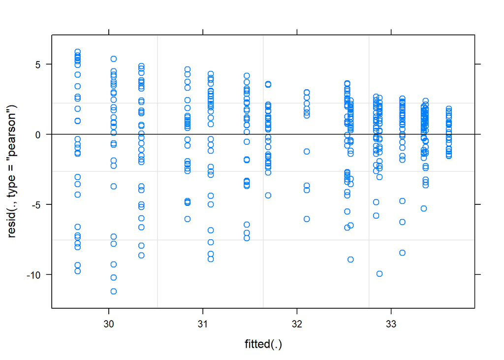

```r
plot(eggperimdiamfin)
```

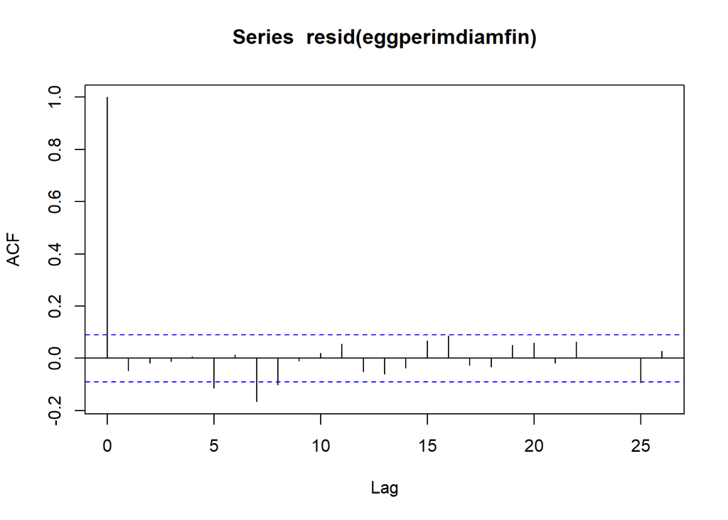

```r
acf(resid(eggperimdiamfin))
```

```r
shapiro.test(resid(eggperimdiamfin))
```

```
##
##  Shapiro-Wilk normality test
##
## data:  resid(eggperimdiamfin)
## W = 0.91879, p-value = 3.975e-15
```

```r
summary(eggperimdiamfin)
```

```
## Linear mixed model fit by REML. t-tests use Satterthwaite's method [
## lmerModLmerTest]
## Formula: EggPerimDiamRat^3 ~ (1 | FemaleID)
##    Data: CalEggs
##
## REML criterion at convergence: 2392.4
##
## Scaled residuals:
##     Min      1Q  Median      3Q     Max
## -3.6515 -0.4412  0.2489  0.6144  1.9238
##
## Random effects:
##  Groups   Name        Variance Std.Dev.
##  FemaleID (Intercept) 1.898    1.378
##  Residual             9.423    3.070
## Number of obs: 465, groups:  FemaleID, 16
##
## Fixed effects:
##             Estimate Std. Error      df t value Pr(>|t|)
## (Intercept)  31.9698     0.3739 15.2629    85.5   <2e-16 ***
## ---
## Signif. codes:  0 '***' 0.001 '**' 0.01 '*' 0.05 '.' 0.1 ' ' 1
```

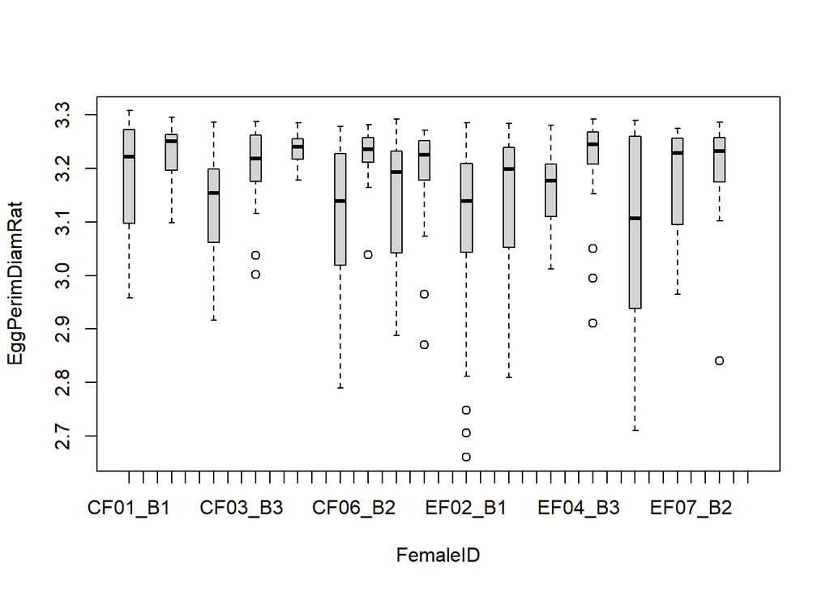

```r
plot(EggPerimDiamRat~FemaleID, data=CalEggs)
```

Egg data don’t meet assumption of normality according to Shapiro-Wilk, what is the best next step?

Choosing mean or median for larvae length data

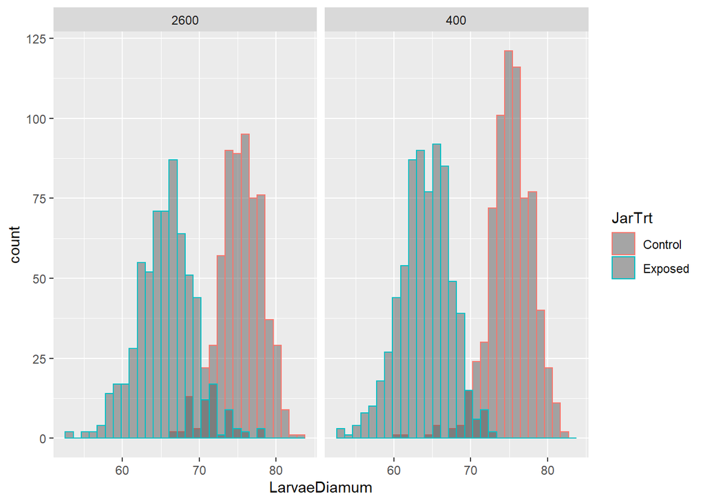

```r
ggplot(LarvaeDat, aes(x=LarvaeDiamum, color=JarTrt))+
  geom_histogram(alpha=0.5, position="identity") +
  facet_grid(~ParentTrt)
```

```r
larvmeans<- aggregate(LarvaeDiamum~ParentTrt*JarTrt, data=LarvaeDat, FUN=mean)
larvmedians<- aggregate(LarvaeDiamum~ParentTrt*JarTrt, data=LarvaeDat, FUN=median)
view(larvmeans)
view(larvmedians)
#I think we can use the mean for these data

#look for the number of jars in each treatment
larvjarn<- aggregate(LarvaeDiamum~ParentTrt*JarTrt, data=LarvByJarDat, FUN=length)
```

Look at the larvae diameter data Use fixed effect for adult treatment and larvae treatment as covariate

```r
larvlen<-lmer(LarvaeDiamum~ParentTrt*JarSatArg_SW+ (1|FemaleID)+(1|MaleID)+(1|CrossID)+(1|JarID)+(1|JarSeatable)+(1|TrtTankID)+(1|MaleTrtTankID), data=LarvaeDat)
```

```
## boundary (singular) fit: see ?isSingular
```

```r
steppedlarvlen<-step(larvlen)
```

```
## boundary (singular) fit: see ?isSingular
## boundary (singular) fit: see ?isSingular
## boundary (singular) fit: see ?isSingular
## boundary (singular) fit: see ?isSingular
```

```
## boundary (singular) fit: see ?isSingular
## boundary (singular) fit: see ?isSingular
```

```
## boundary (singular) fit: see ?isSingular
## boundary (singular) fit: see ?isSingular
## boundary (singular) fit: see ?isSingular
```

```r
print(steppedlarvlen)
```

```
## Backward reduced random-effect table:
##
##                     Eliminated npar  logLik   AIC     LRT Df Pr(>Chisq)
## <none>                           12 -6742.9 13510
## (1 | MaleTrtTankID)          1   11 -6742.9 13508   0.000  1    1.00000
## (1 | TrtTankID)              2   10 -6742.9 13506   0.000  1    0.99693
## (1 | CrossID)                3    9 -6743.0 13504   0.206  1    0.64966
## (1 | FemaleID)               0    8 -6756.0 13528  25.930  1   3.54e-07 ***
## (1 | MaleID)                 0    8 -6748.2 13512  10.301  1    0.00133 **
## (1 | JarID)                  0    8 -6860.5 13737 235.084  1  < 2.2e-16 ***
## (1 | JarSeatable)            0    8 -6746.3 13509   6.587  1    0.01027 *
## ---
## Signif. codes:  0 '***' 0.001 '**' 0.01 '*' 0.05 '.' 0.1 ' ' 1
##
## Backward reduced fixed-effect table:
## Degrees of freedom method: Satterthwaite
##
##                        Eliminated Sum Sq Mean Sq NumDF DenDF F value   Pr(>F)
## ParentTrt:JarSatArg_SW          0  57.92   57.92     1   240   7.518 0.006569
##
## ParentTrt:JarSatArg_SW **
## ---
## Signif. codes:  0 '***' 0.001 '**' 0.01 '*' 0.05 '.' 0.1 ' ' 1
##
## Model found:
## LarvaeDiamum ~ ParentTrt + JarSatArg_SW + (1 | FemaleID) + (1 |
##     MaleID) + (1 | JarID) + (1 | JarSeatable) + ParentTrt:JarSatArg_SW
```

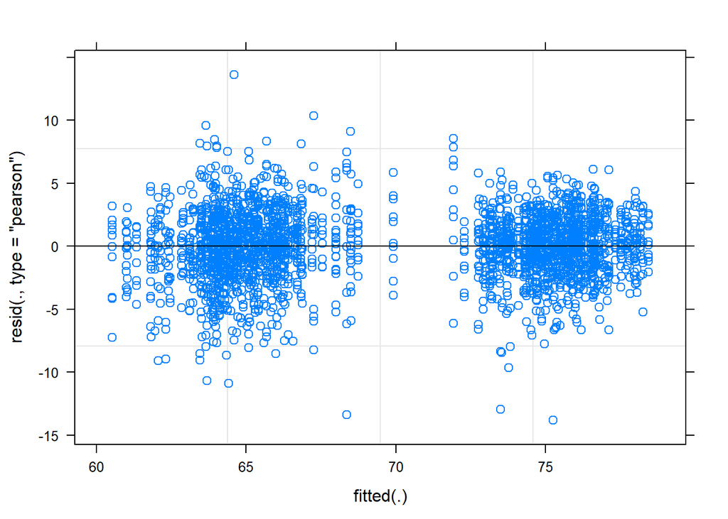

```r
#final model chosen by the lme4 step function: y~ParentTrt*JarSatArg_SW +(1|FemaleID)+(1|MaleID)+(1|JarID)+ (1|JarSeatable)
larvlenfin<- lmer(LarvaeDiamum~ParentTrt*JarSatArg_SW+ (1|FemaleID)+(1|MaleID)+(1|JarID)+ (1|JarSeatable), data=LarvaeDat,control = lmerControl(optimizer ='optimx', optCtrl=list(method='nlminb')))

#check the final model to see that it meets assumptions
plot(larvlenfin) #seems to meet assumption of linearity and homoscedasticity
```

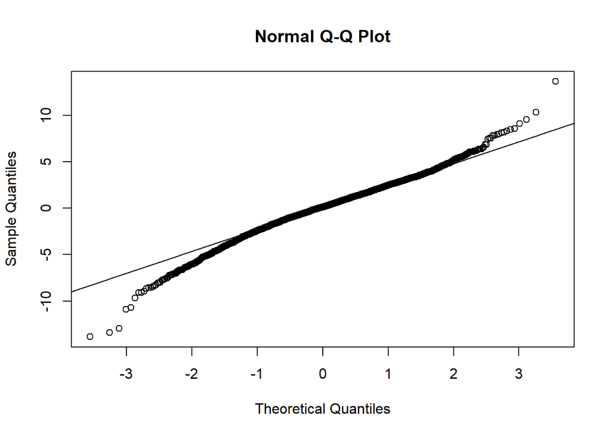

```r
qqnorm(resid(larvlenfin))
qqline(resid(larvlenfin)) #has relatively long tails, I think this should be acceptable
```

```r
shapiro.test(resid(larvlenfin))
```

```
##
##  Shapiro-Wilk normality test
##
## data:  resid(larvlenfin)
## W = 0.98412, p-value < 2.2e-16
```

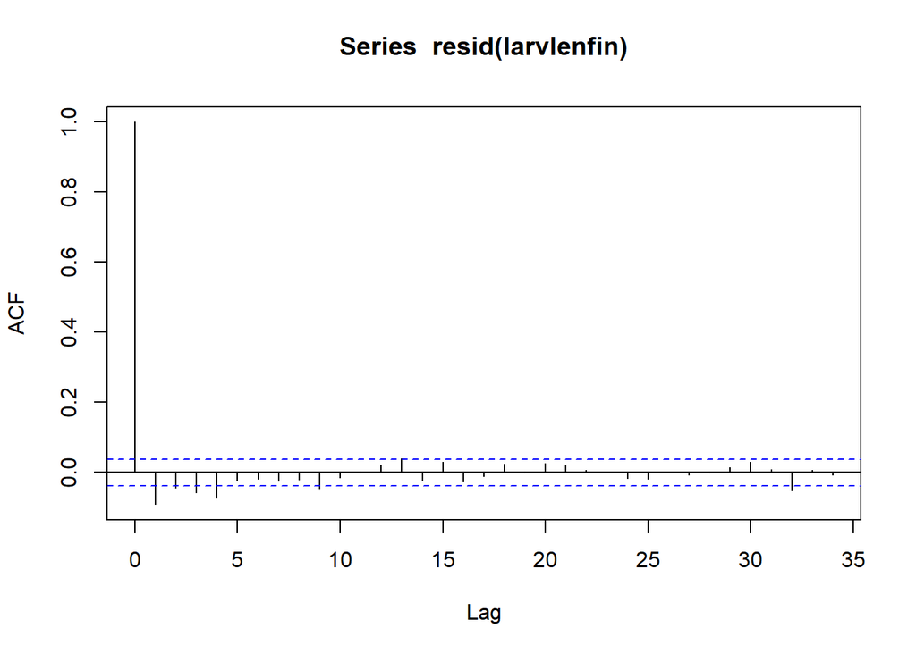

```r
acf(resid(larvlenfin)) #this looks good
```

```r
summary(larvlenfin)
```

```
## Linear mixed model fit by REML. t-tests use Satterthwaite's method [
## lmerModLmerTest]
## Formula: LarvaeDiamum ~ ParentTrt * JarSatArg_SW + (1 | FemaleID) + (1 |
##     MaleID) + (1 | JarID) + (1 | JarSeatable)
##    Data: LarvaeDat
## Control: lmerControl(optimizer = "optimx", optCtrl = list(method = "nlminb"))
##
## REML criterion at convergence: 13486
##
## Scaled residuals:
##     Min      1Q  Median      3Q     Max
## -4.9834 -0.5501  0.0470  0.5968  4.9074
##
## Random effects:
##  Groups      Name        Variance Std.Dev.
##  JarID       (Intercept) 1.8949   1.3766
##  FemaleID    (Intercept) 0.6748   0.8214
##  MaleID      (Intercept) 0.3251   0.5702
##  JarSeatable (Intercept) 0.1607   0.4009
##  Residual                7.7042   2.7756
## Number of obs: 2688, groups:
## JarID, 269; FemaleID, 15; MaleID, 11; JarSeatable, 3
##
## Fixed effects:
##                           Estimate Std. Error       df t value Pr(>|t|)
## (Intercept)                63.1636     0.5231  19.0381 120.743  < 2e-16 ***
## ParentTrt400               -1.6387     0.6543  24.2150  -2.505  0.01938 *
## JarSatArg_SW               20.0359     0.5941 240.5747  33.727  < 2e-16 ***
## ParentTrt400:JarSatArg_SW   2.2122     0.8068 240.0007   2.742  0.00657 **
## ---
## Signif. codes:  0 '***' 0.001 '**' 0.01 '*' 0.05 '.' 0.1 ' ' 1
##
## Correlation of Fixed Effects:
##             (Intr) PrT400 JSA_SW
## ParntTrt400 -0.642
## JarStArg_SW -0.418  0.332
## PT400:JSA_S  0.306 -0.452 -0.731
```

### Is it okay to just use the visual assessment to look at assumptions?

Analyze larvae growth with adult trt as fixed effect and jar as covariate

```r
larvgrow<-lmer(GrowthPerDay~ParentTrt*JarSatArg_SW+(1|MaleID)+(1|CrossID)+(1|JarID) +(1|JarSeatable)+(1|TrtTankID)+(1|MaleTrtTankID), data=LarvaeDat)
```

```
## boundary (singular) fit: see ?isSingular
```

```r
steppedlarvgrow<- step(larvgrow)
```

```
## boundary (singular) fit: see ?isSingular
```

```
## boundary (singular) fit: see ?isSingular
## boundary (singular) fit: see ?isSingular
## boundary (singular) fit: see ?isSingular
## boundary (singular) fit: see ?isSingular
## boundary (singular) fit: see ?isSingular
## boundary (singular) fit: see ?isSingular
## boundary (singular) fit: see ?isSingular
## boundary (singular) fit: see ?isSingular
```

```r
print(steppedlarvgrow)
```

```
## Backward reduced random-effect table:
##
##                     Eliminated npar  logLik    AIC     LRT Df Pr(>Chisq)
## <none>                           11 -3825.4 7672.8
## (1 | MaleID)                 1   10 -3825.4 7670.8   0.000  1   1.000000
## (1 | MaleTrtTankID)          2    9 -3825.4 7668.8   0.000  1   1.000000
## (1 | TrtTankID)              3    8 -3825.7 7667.4   0.628  1   0.428240
## (1 | CrossID)                0    7 -3896.2 7806.4 140.965  1  < 2.2e-16 ***
## (1 | JarID)                  0    7 -3932.6 7879.1 213.686  1  < 2.2e-16 ***
## (1 | JarSeatable)            0    7 -3829.0 7672.1   6.638  1   0.009981 **
## ---
## Signif. codes:  0 '***' 0.001 '**' 0.01 '*' 0.05 '.' 0.1 ' ' 1
##
## Backward reduced fixed-effect table:
## Degrees of freedom method: Satterthwaite
##
##                        Eliminated Sum Sq Mean Sq NumDF  DenDF F value   Pr(>F)
## ParentTrt:JarSatArg_SW          0 6.6358  6.6358     1 220.29  7.7519 0.005832
##
## ParentTrt:JarSatArg_SW **
## ---
## Signif. codes:  0 '***' 0.001 '**' 0.01 '*' 0.05 '.' 0.1 ' ' 1
##
## Model found:
## GrowthPerDay ~ ParentTrt + JarSatArg_SW + (1 | CrossID) + (1 |
##     JarID) + (1 | JarSeatable) + ParentTrt:JarSatArg_SW
```

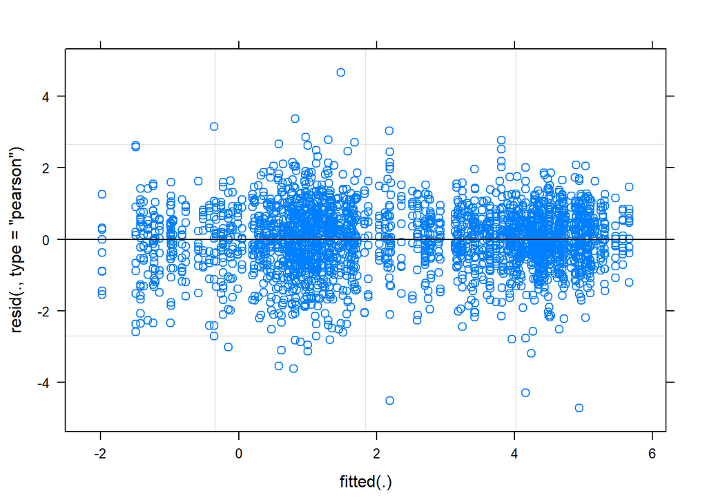

```r
#final model chosen by the lme4 step function: y~SatCalcite_ATDIC*JarTrt+ (1|CrossID)+ (1|JarID) + (1|JarSeatable)
larvgrowfin<- lmer(GrowthPerDay~ParentTrt*JarSatArg_SW+(1|CrossID)+ (1|JarID) + (1|JarSeatable), data=LarvaeDat)
#check the final model to see that it meets assumptions
plot(larvgrowfin) #seems to meet assumption of linearity and homoscedasticity
```

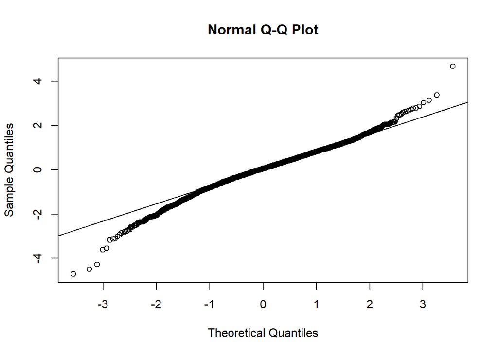

```r
qqnorm(resid(larvgrowfin))
qqline(resid(larvgrowfin)) #has relatively long tails, based on scale I think it reasonably meets assumption of normality.
```

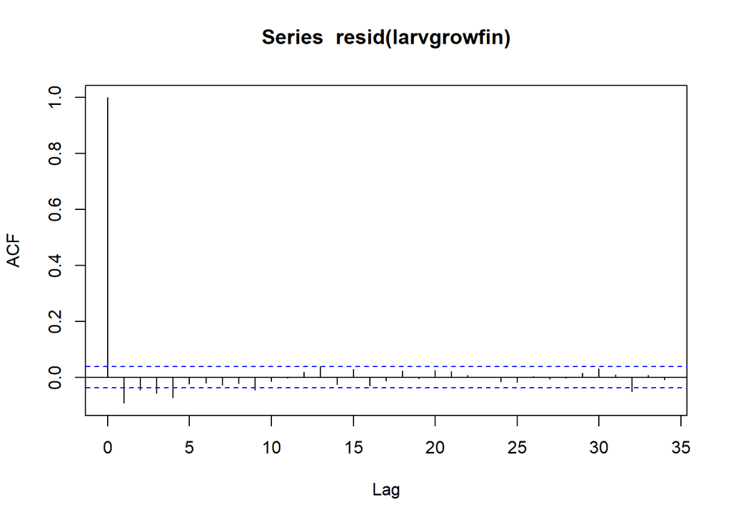

```r
acf(resid(larvgrowfin))
```

```r
shapiro.test(resid(larvgrowfin)) #doesn't meet assumption of normality, but it looks fine to me.
```

```
##
##  Shapiro-Wilk normality test
##
## data:  resid(larvgrowfin)
## W = 0.9835, p-value < 2.2e-16
```

```r
summary(larvgrowfin)
```

```
## Linear mixed model fit by REML. t-tests use Satterthwaite's method [
## lmerModLmerTest]
## Formula: GrowthPerDay ~ ParentTrt * JarSatArg_SW + (1 | CrossID) + (1 |
##     JarID) + (1 | JarSeatable)
##    Data: LarvaeDat
##
## REML criterion at convergence: 7651.4
##
## Scaled residuals:
##     Min      1Q  Median      3Q     Max
## -5.0980 -0.5360  0.0474  0.6079  5.0416
##
## Random effects:
##  Groups      Name        Variance Std.Dev.
##  JarID       (Intercept) 0.20664  0.4546
##  CrossID     (Intercept) 0.44775  0.6691
##  JarSeatable (Intercept) 0.01783  0.1335
##  Residual                0.85602  0.9252
## Number of obs: 2688, groups:  JarID, 269; CrossID, 45; JarSeatable, 3
##
## Fixed effects:
##                           Estimate Std. Error       df t value Pr(>|t|)
## (Intercept)                 0.3907     0.1867  31.7296   2.093  0.04442 *
## ParentTrt400               -1.0383     0.2323  63.0800  -4.470 3.32e-05 ***
## JarSatArg_SW                6.6852     0.1970 220.8566  33.936  < 2e-16 ***
## ParentTrt400:JarSatArg_SW   0.7449     0.2675 220.2898   2.784  0.00583 **
## ---
## Signif. codes:  0 '***' 0.001 '**' 0.01 '*' 0.05 '.' 0.1 ' ' 1
##
## Correlation of Fixed Effects:
##             (Intr) PrT400 JSA_SW
## ParntTrt400 -0.666
## JarStArg_SW -0.388  0.309
## PT400:JSA_S  0.283 -0.422 -0.731
```

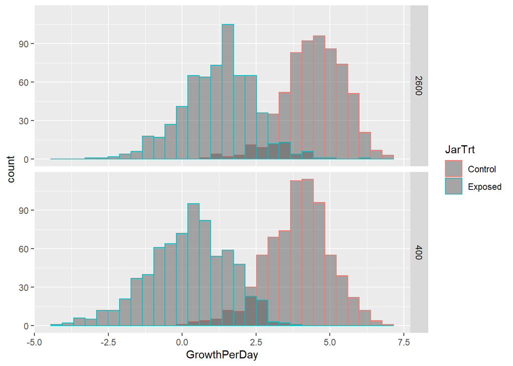

```r
ggplot(LarvaeDat, aes(x=GrowthPerDay,color=JarTrt))+
  geom_histogram(alpha=0.5, position="identity")+
  facet_grid(ParentTrt~.)
```

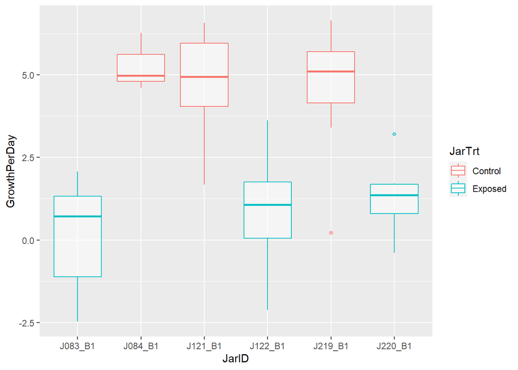

```r
ProblemCross<- subset(LarvaeDat, CrossID=="CF02_CM02_B1_QG")# I don't know why I labeled this as a problem cross. It may have previously had mislabeled control vs OA jars
ggplot(ProblemCross, aes(y=GrowthPerDay,x=JarID, color=JarTrt))+
  geom_boxplot(alpha=0.5, position="identity")
```

Look at larvae area; Parent Trt as fixed effect and Jar Treatment as covariate

```r
larvareat<-lmer(sqrt(LarvaeAreaum2)~ParentTrt*JarSatArg_SW+ (1|FemaleID)+(1|MaleID)+(1|CrossID)+(1|JarSeatable)+(1|JarID)+(1|TrtTankID)+(1|MaleTrtTankID) , data=LarvaeDat)
```

```
## boundary (singular) fit: see ?isSingular
```

```r
steppedlarvareat<-step(larvareat)
```

```
## boundary (singular) fit: see ?isSingular
## boundary (singular) fit: see ?isSingular
## boundary (singular) fit: see ?isSingular
## boundary (singular) fit: see ?isSingular
## boundary (singular) fit: see ?isSingular
```

```
## boundary (singular) fit: see ?isSingular
## boundary (singular) fit: see ?isSingular
## boundary (singular) fit: see ?isSingular
```

```r
print(steppedlarvareat)
```

```
## Backward reduced random-effect table:
##
##                     Eliminated npar  logLik   AIC     LRT Df Pr(>Chisq)
## <none>                           12 -6168.8 12362
## (1 | MaleTrtTankID)          1   11 -6168.8 12360   0.000  1   1.000000
## (1 | TrtTankID)              2   10 -6168.8 12358   0.000  1   1.000000
## (1 | CrossID)                3    9 -6169.3 12356   0.885  1   0.346742
## (1 | FemaleID)               0    8 -6182.9 12382  27.283  1  1.757e-07 ***
## (1 | MaleID)                 0    8 -6173.9 12364   9.334  1   0.002249 **
## (1 | JarSeatable)            0    8 -6177.1 12370  15.652  1  7.612e-05 ***
## (1 | JarID)                  0    8 -6304.8 12626 271.041  1  < 2.2e-16 ***
## ---
## Signif. codes:  0 '***' 0.001 '**' 0.01 '*' 0.05 '.' 0.1 ' ' 1
##
## Backward reduced fixed-effect table:
## Degrees of freedom method: Satterthwaite
##
##                        Eliminated Sum Sq Mean Sq NumDF  DenDF F value  Pr(>F)
## ParentTrt:JarSatArg_SW          0 20.297  20.297     1 239.96  4.0731 0.04468 *
## ---
## Signif. codes:  0 '***' 0.001 '**' 0.01 '*' 0.05 '.' 0.1 ' ' 1
##
## Model found:
## sqrt(LarvaeAreaum2) ~ ParentTrt + JarSatArg_SW + (1 | FemaleID) +
##     (1 | MaleID) + (1 | JarSeatable) + (1 | JarID) + ParentTrt:JarSatArg_SW
```

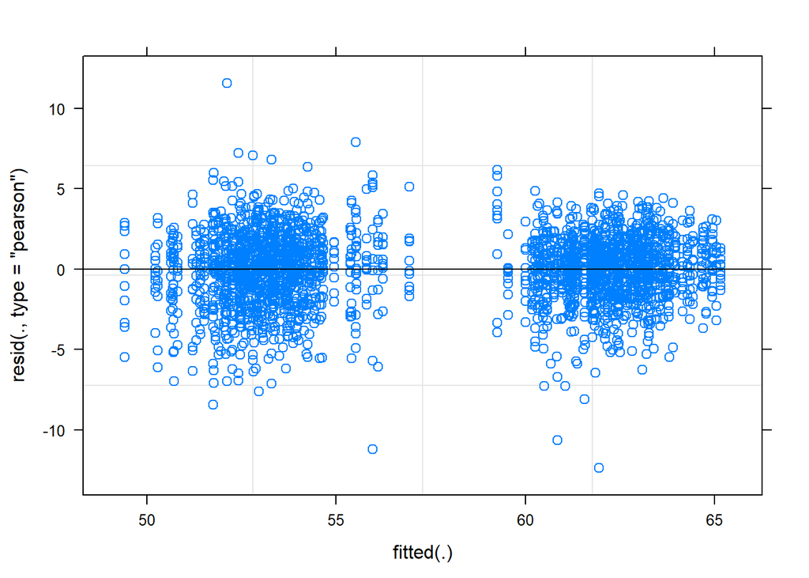

```r
#final model chosen by the lme4 step function: y~SatArag_ATDIC*JarTrt+(1|FemaleID)+(1|MaleID)+(1|JarID)+(1|JarSeatable)
larvareafint<- lmer(sqrt(LarvaeAreaum2)~ParentTrt*JarSatArg_SW+(1|FemaleID)+(1|MaleID)+(1|JarID)+(1|JarSeatable), data=LarvaeDat, control = lmerControl(optimizer ='optimx', optCtrl=list(method='nlminb')))
plot(larvareafint) #seems to meet assumption of linearity and homoscedasticity
```

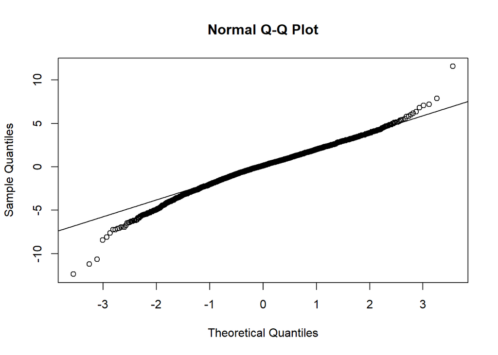

```r
qqnorm(resid(larvareafint))
qqline(resid(larvareafint)) #this seems to have improved it
```

```r
shapiro.test(resid(larvareafint)) #doesn't meet assumption according to shapiro.
```

```
##
##  Shapiro-Wilk normality test
##
## data:  resid(larvareafint)
## W = 0.98359, p-value < 2.2e-16
```

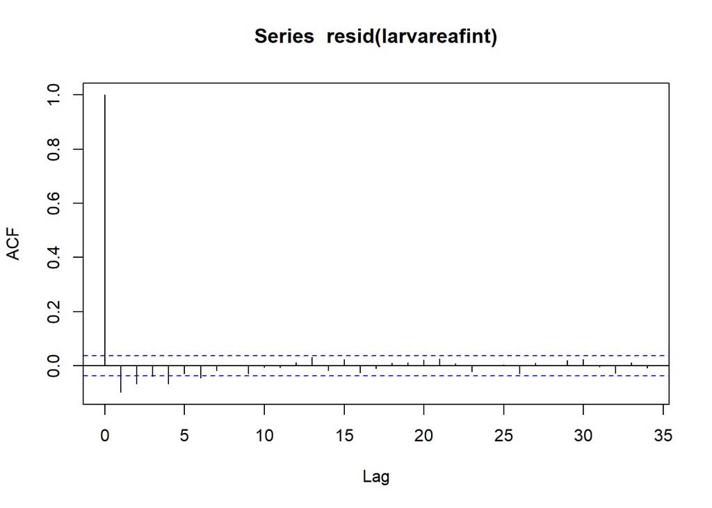

```r
acf(resid(larvareafint)) #this looks fine to me.
```

```r
summary(larvareafint)
```

```
## Linear mixed model fit by REML. t-tests use Satterthwaite's method [
## lmerModLmerTest]
## Formula: sqrt(LarvaeAreaum2) ~ ParentTrt * JarSatArg_SW + (1 | FemaleID) +
##     (1 | MaleID) + (1 | JarID) + (1 | JarSeatable)
##    Data: LarvaeDat
## Control: lmerControl(optimizer = "optimx", optCtrl = list(method = "nlminb"))
##
## REML criterion at convergence: 12338.5
##
## Scaled residuals:
##     Min      1Q  Median      3Q     Max
## -5.5398 -0.5580  0.0596  0.6141  5.1819
##
## Random effects:
##  Groups      Name        Variance Std.Dev.
##  JarID       (Intercept) 1.3663   1.1689
##  FemaleID    (Intercept) 0.4830   0.6950
##  MaleID      (Intercept) 0.2145   0.4632
##  JarSeatable (Intercept) 0.2297   0.4793
##  Residual                4.9832   2.2323
## Number of obs: 2688, groups:
## JarID, 269; FemaleID, 15; MaleID, 11; JarSeatable, 3
##
## Fixed effects:
##                           Estimate Std. Error       df t value Pr(>|t|)
## (Intercept)                51.4337     0.4796  11.9549 107.252   <2e-16 ***
## ParentTrt400               -1.0598     0.5456  24.2538  -1.943   0.0638 .
## JarSatArg_SW               17.8623     0.4970 240.2788  35.939   <2e-16 ***
## ParentTrt400:JarSatArg_SW   1.3619     0.6748 239.9606   2.018   0.0447 *
## ---
## Signif. codes:  0 '***' 0.001 '**' 0.01 '*' 0.05 '.' 0.1 ' ' 1
##
## Correlation of Fixed Effects:
##             (Intr) PrT400 JSA_SW
## ParntTrt400 -0.585
## JarStArg_SW -0.381  0.333
## PT400:JSA_S  0.279 -0.453 -0.731
```

Characterize the larvae by the ratio of major and minor axis

```r
larvrat<-lmer(MajMinRat~ParentTrt*JarSatArg_SW+ (1|FemaleID)+(1|MaleID)+(1|JarSeatable)+(1|JarID)+(1|AccTankID) +(1|CrossID)++(1|TrtTankID)+(1|MaleTrtTankID), data=LarvaeDat)
```

```
## boundary (singular) fit: see ?isSingular
```